# Determinantes de los Ingresos Familiares mediante Regresión Lineal Múltiple: Un Estudio Empírico con Microdatos de la ECV DANE 2024

Barros Rayo Alejandro (2415837), Muñoz Portela Diego Fernando (2415620), Portilla Aguirre Johan Camilo (2422468), Aguirre Aldana Joan Sebastian (2419550)

09 de octubre de 2025

# 1 Introducción

Entender los determinantes del ingreso familiar constituye uno de los elementos centrales para el diseño de políticas públicas que serán centradas en la reducción de la pobreza y la promoción del desarrollo socioeconómico equitativo (Muñoz, 2004). En Colombia, esta problemática adquiere mucha relevancia en regiones como el Pacífico, la cual será nuestro objeto de estudio, caracterizada por persistentes brechas de desigualdad y condiciones socioeconómicas adversas que contrastan con la riqueza de sus recursos naturales y diversidad cultural (Galvis-Aponte et al., 2016)

La región pacífica colombiana, conformada por los departamentos de Chocó, Cauca, Nariño y Valle del Cauca, cuenta con una población aproximada de 0.55 millones, 1.56 millones, 1.70 millones y 4.64 millones respectivamente. En estos departamentos predominan las comunidades afrodescendientes, las cuales representan alrededor del 74.4% de la población en Chocó, 22.8% en Nariño, 20.0% en Cauca y 17.5% en Valle del Cauca. y con una población indígena cerca del 15% en Chocó (según censo 2018), 15.9% en Nariño y 25.4% en Cauca, mientras que en Valle del Cauca apenas alcanza el 0.8%.

Según el DANE, la incidencia de pobreza monetaria en 2024 fue extremadamente alta en la región Pacífica: Chocó 67.4%, Cauca 43.1%, Nariño 39.2% y Valle del Cauca 25.7%. Estos valores superan con creces el promedio nacional (31.8%). En conjunto, estas cifras, sumadas al aislamiento geográfico de la región y a la limitada presencia institucional, reflejan una alta vulnerabilidad socioeconómica en el Pacífico colombiano, lo que resalta la necesidad de analizar detalladamente los factores que afectan la generación de ingresos familiares (Sánchez-Torres, 2024).

En Colombia, la Encuesta Nacional de Calidad de Vida (ECV) es una operación estadística que el DANE realiza con el objeto de recoger información sobre diferentes aspectos y dimensiones del bienestar y las condiciones de vida de los hogares, incluyendo temas como lo son el acceso a bienes y servicios públicos, privados o comunales, salud, educación, atención integral de niños menores de 5 años, entre otros (DANE, 2025). La consideración de estos aspectos hace posible realizar análisis a los factores que explican los diferentes niveles de vida existentes en la sociedad. La Encuesta Nacional de Calidad de Vida (ECV) es, además, la fuente de información del cálculo del Índice de Pobreza Multidimensional, IPM (DNP, 2016).

Adicionalmente, un modelo lineal es una ecuación matemática o representación que describe la relación entre dos o más cantidades, asumiendo que la relación es directa y tiene una tasa de cambio constante (Contreras Navarrete, 2011). Estos han demostrado ser herramientas efectivas para el análisis de los determinantes del ingreso familiar, permitiendo cuantificar el efecto de variables socioeconómicas y demográficas sobre los ingresos de los hogares (Gaviria Ríos et al., 2007).

En el contexto específico de la región Pacífica, el análisis de estos determinantes cobra particular importancia debido a las características específicas de su población. Los bajos niveles educativos, la alta informalidad laboral, las estructuras familiares complejas y las condiciones de exclusión social que caracterizan a esta región sugieren que los patrones de determinación del ingreso pueden diferir significativamente de los observados en otras regiones del país (Espinosa-Espinosa, 2021).

El presente estudio aplica un modelo de regresión lineal múltiple utilizando los datos de la ECV para la región Pacífica, con el objetivo de analizar la relación entre el ingreso familiar y un conjunto de variables que incluyen la edad, el departamento, el sexo del jefe de hogar, la cantidad de personas, y el nivel educativo del jefe de hogar. Esta selección de variables se basa tanto en la revisión de la literatura especializada como en las características socioeconómicas específicas de la región Pacífica (Auvert Albornoz, 2014)

# 2 Metodologia

## 2.1 Metodo empleado

El estudio partió de una búsqueda en la página del DANE para obtener una base de datos adecuada, a la que se le aplicaría el método de Regresión Lineal Múltiple. Se seleccionó la Encuesta de Calidad de Vida (ECV) 2024 como fuente de información, reconocida como la principal operación estadística que el DANE realiza para recoger información sobre diferentes aspectos y dimensiones del bienestar y las condiciones de vida de los hogares (DANE, 2024). A partir del archivo original, se seleccionaron las variables a emplear, las cuales como variable dependiente se escogió el ingreso del hogar, y como variables independientes se escogieron la edad, el departamento, el sexo del jefe del hogar, la cantidad de personas que habitan el hogar, el nivel educativo alcanzado por el jefe de hogar, y la cantidad de horas trabajadas la semana pasada. Se prosiguió con un filtro en la base de datos de estas variables para tener solamente los datos de interés, como lo es que nuestro estudio se realizará en la región pacífica.

Al analizar los recursos o capitales, muchas veces los datos reales no siempre se comportan de manera lineal. Muchas veces, la variable dependiente puede tener una relación asimétrica. Para contrarrestar esto, se utilizó la función logaritmo natural de una variable en vez de la variable en sí. Esto tiene muchas propiedades que pueden mejorar los modelos, ya que puede transformar una relación no lineal en una lineal (Vidal Sánchez, 2024). Además, según la University of Virginia Library (2018), aplicar un logaritmo ayuda a “estabilizar la varianza y reducir la asimetría” de los datos, lo que contribuye a que los modelos cumplan mejor los supuestos estadísticos.

Previo a la estimación se realizó un análisis descriptivo por medio de tablas de frecuencias, medias, desviaciones estándar y revisión de extremos con el fin de caracterizar la muestra, detectar valores atípicos y decidir las codificaciones definitivas. A continuación, se estimaron modelos de Regresión Lineal Múltiple (Mínimos Cuadrados Ordinarios), incorporando los controles demográficos, laborales y educativos señalados. La regresión lineal múltiple permite generar un modelo lineal en el que el valor de la variable dependiente se determina a partir de un conjunto de variables predictoras, siguiendo la ecuación: Yi = (β₀ + β₁X₁ᵢ + β₂X₂ᵢ + ⋯ + βₙXₙᵢ) + eᵢ (Ciencia de Datos, 2017)

Para comprobar la validez de las inferencias se efectuó un diagnóstico gráfico y analítico de los supuestos clásicos del modelo de regresión lineal múltiple. Los principales supuestos evaluados fueron: linealidad (la relación entre las variables independientes y la dependiente es lineal), independencia (los residuos son independientes entre sí), homocedasticidad (la varianza de los residuos es constante para cada valor de las variables independientes), normalidad (los residuos se distribuyen normalmente con media cero), y no multicolinealidad (no existe relación lineal exacta entre las variables independientes) (Marín, 2018).

Tambien, Se calculó el Factor de Inflación de la Varianza (VIF) para cada variable independiente con el fin de detectar la presencia de multicolinealidad. Un VIF menor a 5 indica que no existen problemas graves de colinealidad, mientras que valores superiores a 10 señalan multicolinealidad severa que puede distorsionar las estimaciones de los coeficientes (Dormann et al., 2013).

La validación de estos supuestos se realizó mediante: visualización de residuos (gráfico de residuos vs valores ajustados) para evaluar homocedasticidad y linealidad, gráfico Q-Q para verificar la normalidad aproximada de residuos, pruebas de heterocedasticidad, y cálculo de medidas de influencia como las distancias de Cook para identificar observaciones atípicas que pudieran estar afectando significativamente los resultados del modelo (Barragán-Moreno et al., 2024). El análisis de los residuos es fundamental en la regresión, ya que informa sobre el grado de exactitud de los pronósticos y permite detectar casos atípicos que pueden ayudar a perfeccionar la ecuación de regresión (Marín, 2018)

## 2.2 Variables

Las variables utilizadas en el estudio se dividen en dos grupos: dependientes e independientes. La variable dependiente que fue seleccionada es el ingreso del hogar, la cual busca medir el nivel monetario total percibido por los miembros del hogar. Este indicador refleja el grado de bienestar económico, la capacidad de consumo y las oportunidades de inversión en educación, salud y vivienda (Muñoz, 2004).

En cuanto a las variables independientes, se consideran varios factores cuyo nivel de significancia resulta fundamental para explicar el ingreso. En primer lugar, la edad es un factor que se considera relacionado con una mayor experiencia y, por lo tanto, con mayores ingresos. Sin embargo, las jubilaciones pueden afectar el comportamiento lineal que se esperaría, haciendo que este se estabilice o disminuya (Guataquí, 2009). Por ello, la edad se reconoce como una variable importante para relacionar con los ingresos, ya que estos tienden a variar a lo largo del ciclo de vida laboral. En Colombia, menos de una cuarta parte de los adultos mayores reciben pensión, y los ingresos laborales siguen siendo la principal fuente de sustento incluso en la vejez (Villar et al., 2016)

La región corresponde a la Región Pacífica, la cual se escoge como filtro focal del estudio, dado que es una de las zonas de Colombia más diversas en cuanto a clima, población y condiciones económicas, lo que se supone que permitirá realizar un análisis más preciso de las dinámicas económicas regionales. Los estudios muestran que existen diferencias salariales significativas según el área geográfica, lo que da evidencia de segmentación del mercado laboral en Colombia (Mesa et al., 2008)

El sexo (género) se incluye porque influye de manera sistemática en las oportunidades laborales y en la remuneración. A nivel agregado, las mujeres suelen enfrentar brechas salariales respecto a los hombres, mayor participación en empleos de menor remuneración o en sectores con alta informalidad, y sobrecarga de responsabilidades de cuidado que limitan las horas trabajadas o la disponibilidad para empleos formales (DANE, 2024). La brecha salarial en Colombia no cede, las mujeres continúan en desventaja, ganando 6,3% menos que los hombres en 2021. Por tanto, el indicador de sexo permite captar efectos de segregación ocupacional, diferencias en la participación laboral y posibles discriminaciones salariales (Gómez-Segura, 2018).

La cantidad de personas en el hogar, porque afecta la distribución de recursos y la presión sobre el ingreso total del hogar. Hogares con mayor número de miembros enfrentan mayores necesidades de consumo y, salvo que aumente proporcionalmente el número de miembros que generan ingresos, presentan menores ingresos per cápita (Lora, 2025). Además, el tamaño del hogar está ligado a razones demográficas (niñez, dependencia de adultos mayores) que inciden en la capacidad de ahorro e inversión en capital humano. Los estudios muestran que las economías de escala y las escalas de equivalencia deben considerarse al analizar el bienestar de los hogares según su composición demográfica (Muñoz & Ramos, 2002).

La educación es otra variable para tomar en cuenta, las personas con mayor nivel educativo tienden a acceder a empleos mejor remunerados y con mayores oportunidades de ascenso, además de aumentar su productividad y capital humano (Meza Buchely, 2020). Por lo tanto, se espera que, a mayor grado educativo alcanzado, el ingreso también sea más alto. Los estudios econométricos confirman que la educación tiene una relación significativa en la disminución del Coeficiente de Gini en Colombia, y que los retornos de la escolaridad guardan relación directa y permanente con el salario (Buelvas, 2019). Como señalan Psacharopoulos y Patrinos (2018), “por esta razón la educación, y en particular la educación superior, constituyen un elemento importante dentro de los múltiples determinantes del crecimiento económico.”

La cantidad de horas trabajadas la semana pasada constituye una variable fundamental que refleja la intensidad laboral y mantiene una relación directa con el nivel de ingresos percibidos por los trabajadores. En Colombia, donde la jornada laboral máxima se ha reducido gradualmente desde 48 a 47 horas semanales en 2023, con proyección a 42 horas en 2026 (Ministerio del Trabajo, 2023), los estudios empíricos demuestran que existe una correlación positiva entre horas trabajadas e ingresos laborales. Guataquí et al. (2009) encontraron que los asalariados, quienes trabajaban en promedio 49.9 horas semanales, tenían ingresos por hora 18% mayores que los trabajadores cuenta propia que laboraban 47.8 horas semanales. En el contexto de la región Pacífica, donde predominan actividades informales, las horas trabajadas adquieren particular relevancia como mecanismo compensatorio, ya que trabajadores en sectores informales requieren jornadas extendidas para obtener ingresos equiparables al salario mínimo (Vargas et al., 2015).

## 2.3 Descripcion del modelo

Tabla de Variables del Modelo de Regresión

[output not shown]

Nota: Fuente: Elaboración propia con base en ECV DANE 2024

### 2.3.1 Ecuación del modelo:

La ecuación empleada en el modelo de regresión lineal múltiple tiene como objetivo expresar el logaritmo natural del ingreso del hogar como una combinación lineal de distintas variables socioeconómicas, demográficas y laborales. Cada término en la ecuación corresponde al efecto específico de una variable explicativa, permitiendo estimar cómo varía el ingreso familiar ante cambios unitarios en cada una de ellas, manteniendo las demás constantes.

El término independiente (β0) representa el valor esperado del logaritmo del ingreso familiar cuando todas las variables explicativas toman el valor de referencia o cero. Los coeficientes asociados a cada variable (βj) indican el cambio porcentual aproximado en el ingreso familiar ante una variación unitaria en cada factor, gracias a la transformación logarítmica de la variable dependiente. Por ejemplo, si el coeficiente de la edad es 0.02, se interpreta que un año adicional de edad del jefe de hogar se asocia con un aumento aproximado del 2% en el ingreso, controlando por los demás factores.

Las variables categóricas (como sexo, estudios o departamento) se interpretan en relación con la categoría de referencia, por lo que el coeficiente refleja la diferencia porcentual media frente a esa categoría. Finalmente, el término de error (εi) agrupa factores no observados o no incluidos en el modelo, que también inciden en el ingreso familiar. De esta forma, la estructura de la ecuación proporciona una visión detallada y cuantificable del papel de cada determinante sobre el bienestar económico de los hogares analizados.

**Ecuación del modelo**

## 2.4 Base de datos del estudio

Para el presente trabajo, se utiliza la base de datos de la ECV 2024 filtrada específicamente para la región Pacífica, que incluye los departamentos de Chocó, Cauca, Nariño y Valle del Cauca. La base de datos ha sido depurada y contiene únicamente las variables de interés para el modelo de regresión lineal:

| Departamento | Ingreso del hogar | C. personas en el hogar | Sexo | Edad | Estudios | Horas trabajadas la semana pasada |
| --- | --- | --- | --- | --- | --- | --- |
| Chocó | 1600000 | 1 | Hombre | 68 | Universitaria | 20 |
| Chocó | 1458333.3333 | 3 | Hombre | 22 | Técnica/Tecnológica | 30 |
| Chocó | 1458333.3333 | 3 | Hombre | 22 | Técnica/Tecnológica | 41 |
| Chocó | 6183000 | 1 | Hombre | 35 | Secundaria | 40 |
| Chocó | 8700000 | 1 | Hombre | 75 | Secundaria | 48 |
| Chocó | 6425000 | 1 | Mujer | 51 | Universitaria | 40 |
| Chocó | 4933333.3333 | 1 | Hombre | 44 | Universitaria | 40 |
| Chocó | 873333.33333 | 2 | Hombre | 69 | Secundaria | 39 |
| Chocó | 1500000 | 1 | Hombre | 33 | Universitaria | 20 |
| Chocó | 2700000 | 2 | Hombre | 50 | Secundaria | 36 |

[output cut: 7170 more lines]

# 3 Resultados descriptivos

## 3.1 Análisis Univariado de las Variables del Modelo

### 3.1.1 Caracterización de la Variable Dependiente: Ingreso Total del Hogar

Tabla 1: Estadísticas Descriptivas del ingreso del hogar por Departamento

| Departamento | N | Ingreso promedio | Desv. Estándar | Mínimo | Máximo |
| --- | --- | --- | --- | --- | --- |
| Cauca | 1912 | 2602230 | 3867074 | 1416.667 | 44656667 |
| Chocó | 1088 | 2039157 | 3261609 | 6666.667 | 31566667 |
| Nariño | 2055 | 2432720 | 3567317 | 60000.000 | 43812500 |
| Valle del Cauca | 2125 | 3166932 | 3585574 | 250.000 | 38962000 |

Nota: Fuente: Elaboración propia con base en ECV DANE 2024

[interactive chart not shown]

## 3.2 Variables Explicativas Cuantitativas: Caracterización Estadística

### 3.2.1 Edad del jefe del hogar

Edad del jefe o responsable del hogar, la cual es medida en años tal como la reporta la Encuesta de Calidad de Vida (ECV) 2024. La Tabla 2 resume las estadísticas descriptivas por departamento.

Tabla 2: Estadísticas Descriptivas de la edad del jefe del hogar Agrupadas por departamento

| Código | Edad Promedio | Desv. Estándar de la edad | Mínimo de la edad | Máximo de la edad |
| --- | --- | --- | --- | --- |
| Cauca | 52.6 | 16.02 | 18 | 91 |
| Chocó | 46.9 | 16.47 | 18 | 92 |
| Nariño | 53.6 | 15.24 | 18 | 99 |
| Valle del Cauca | 52.7 | 15.48 | 18 | 98 |

Nota: Fuente: Elaboración propia con base en ECV DANE 2024

Con los datos de la tabla se observa una presencia marcada de adultos en etapa de consolidación laboral y también una porción significativa de personas en edad cercana a la jubilación; las medias departamentales se ubican en la franja alta de la vida productiva, entre aproximadamente 47 y 54 años, y los extremos se extienden desde los 18 hasta casi los 100 años, lo que indica cobertura de todo el ciclo adulto. La desviación estándar, que es de alrededor de 15–17 años según departamento, refleja una dispersión que combina cohortes jóvenes y mayores dentro de cada muestra, generando colas a ambos lados de la distribución. Esta composición etaria sugiere que, en la muestra, los hogares incorporan tanto efectos de experiencia acumulada como situaciones vinculadas a retiro o inactividad por edad avanzada.

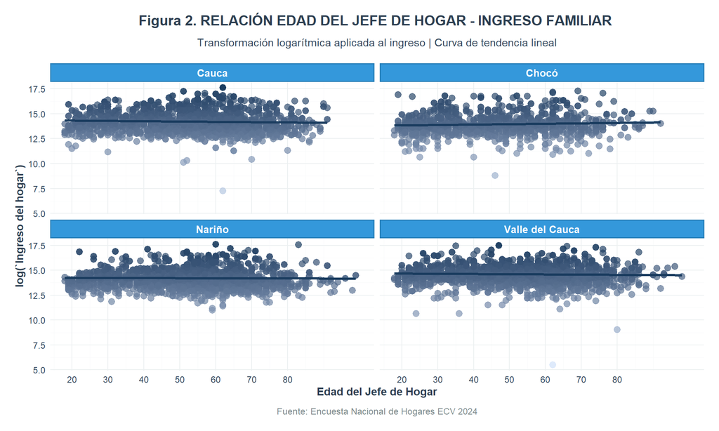

### 3.2.2 Cantidad de personas en el hogar

La cantidad de personas en el hogar se introduce como una variable independiente clave. Las estadísticas descriptivas presentadas en la Tabla 3 revelan la variabilidad transversal entre departamentos, lo cual es fundamental para identificar posibles patrones que el modelo econométrico puede capturar.

Tabla 3: Estadísticas Descriptivas de la cantidad de personas en el hogar Agrupadas por departamento

| Departamento | Cantidad de personas Promedio | Desv. Estándar | Mínimo | Máximo |
| --- | --- | --- | --- | --- |
| Cauca | 2.2 | 1.03 | 1 | 6 |
| Chocó | 2.1 | 1.03 | 1 | 7 |
| Nariño | 2.4 | 1.10 | 1 | 6 |
| Valle del Cauca | 2.5 | 1.24 | 1 | 8 |

Nota: Fuente: Elaboración propia con base en ECV DANE 2024

Los tamaños domésticos observados tienden a concentrarse en valores pequeños (la mayoría entre 1 y 4 integrantes), aunque también existen casos aislados de hogares considerablemente mayores que alargan la cola superior. Los promedios por departamento oscilan en una banda estrecha de entre 2.1 a 2.5 personas, pero esa similitud promedio oculta variaciones en la forma de la distribución, ya que mientras muchos hogares son unipersonales o nucleares, la presencia puntual de hogares con 6–8 miembros muestran arreglos residenciales más complejos presentes en la muestra. La desviación estándar cercana a 1 persona sugiere que, en términos generales, la mayoría de las observaciones se agrupan cerca del promedio, aunque los extremos indican heterogeneidad en tamaños familiares que podría relacionarse con diferencias generacionales, formas de convivencia y arreglos intergeneracionales dentro de la región

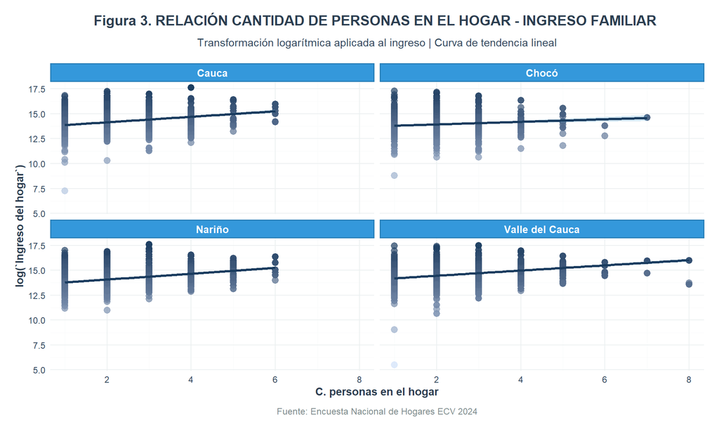

### 3.2.3 Horas trabajadas la semana pasada

Tabla 4: Estadísticas Descriptivas de las horas trabajas la semana pasada por el jefe del hogar en el hogar Agrupadas por departamento

| Departamento | Cantidad de horas promedio trabajadas | Desv. Estándar | Mínimo | Máximo |
| --- | --- | --- | --- | --- |
| Cauca | 36.8 | 14.00 | 2 | 120 |
| Chocó | 31.2 | 15.44 | 1 | 88 |
| Nariño | 36.2 | 15.50 | 1 | 112 |
| Valle del Cauca | 42.3 | 14.06 | 2 | 120 |

Nota: Fuente: Elaboración propia con base en ECV DANE 2024

La variable muestra una distribución amplia y asimetrías notorias, como lo son los promedios departamentales que varían (con Valle del Cauca claramente por encima del resto) y desviaciones estándar elevadas que señalan variabilidad en jornadas recientes. Los valores máximos registrados (hasta 120 horas en algunos casos) generan colas largas en la parte superior de la distribución y reflejan tanto jornadas extraordinarias como registros extremos que conviven con observaciones de jornadas muy reducidas o nulas. La coexistencia de jornadas cortas y registros de alta intensidad productiva implica una muestra con experiencias laborales muy diversas en términos de tiempo efectivo trabajado durante la última semana; esta dispersión se manifiesta en diferencias de concentración y en asimetría positiva en la mayoría de los departamentos

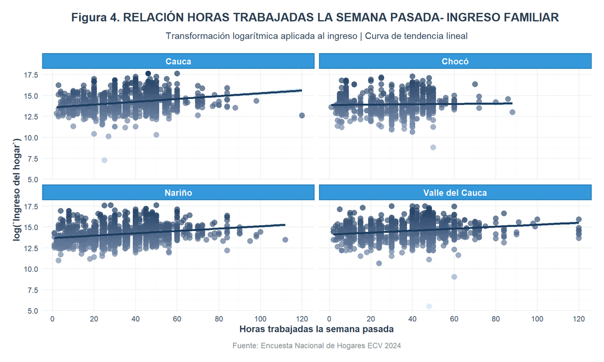

## 3.3 Variables Categóricas: Distribución de Frecuencias

### 3.3.1 Estudios del jefe del hogar

La tabla 5 revela una estructura formativa predominantemente básica en la región Pacífica colombiana. El nivel de secundaria concentra la mayor proporción con 4,992 casos (69.5%), constituyéndose como la característica educativa más representativa entre los jefes de hogar. Le siguen en importancia la formación técnica o tecnológica con 889 casos (12.4%) y la educación universitaria con 774 observaciones (10.8%).

Tabla 5 Distribución de Frecuencias del nivel de estudios del jefe del hogar

| Estudios | Frecuencia | Porcentaje (%) | Porcentaje Acumulado (%) |
| --- | --- | --- | --- |
| Secundaria | 4992 | 69.5 | 69.5 |
| Técnica/Tecnológica | 889 | 12.4 | 81.9 |
| Universitaria | 774 | 10.8 | 92.7 |
| Postgrado | 314 | 4.4 | 97.1 |
| Primaria | 211 | 2.9 | 100.0 |

Nota: Fuente: Elaboración propia con base en ECV DANE 2024

La estudios de postgrado representa apenas el 4.4% (314 casos), mientras que los estudios de educación primaria constituyen el segmento más reducido con solo 211 casos (2.9%). Esta distribución evidencia una pirámide educativa marcadamente amplia en la base y muy estrecha en la cúspide, patrón que sugiere limitaciones en el acceso a educación superior y especializada en la región.

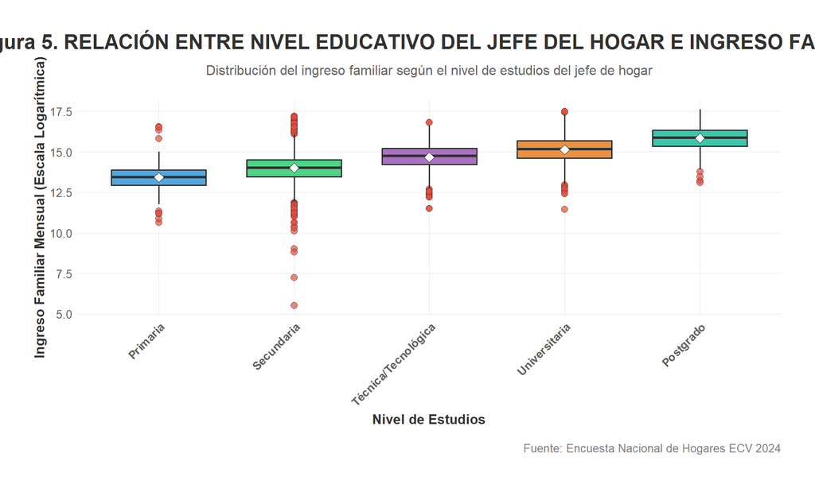

### 3.3.2 Sexo del jefe del hogar

La tabla 6 revela una marcada disparidad de género. Los datos muestran una predominancia significativa de hombres como jefes de hogar, representando el 63.8% del total (4,580 casos), mientras que las mujeres constituyen el 36.2% (2,600 casos). Esta relación de aproximadamente 2:1 evidencia una estructura patriarcal aún persistente en la conformación de los hogares de la región.

Tabla 6 Distribución de Frecuencias del genero del jefe del hogar

| Genero | Frecuencia | Porcentaje (%) | Porcentaje Acumulado (%) |
| --- | --- | --- | --- |
| Hombre | 4580 | 63.8 | 63.8 |
| Mujer | 2600 | 36.2 | 100.0 |

Nota: Fuente: Elaboración propia con base en ECV DANE 2024

La siguiente gráfica muestra cómo se distribuye el ingreso familiar mensual en las muestras. Las cajas de ambas categorías tienen una forma muy parecida y las líneas de la mediana quedan en posiciones similares, lo que indica que los valores centrales del ingreso familiar encabezados por hombres y encabezados por mujeres son comparables en la muestra. Al mismo tiempo, en ambos grupos se observan puntos atípicos por encima y por debajo del rango intercuartílico, hay observaciones con ingresos muy superiores a la mediana y también con ingresos notablemente bajos, lo que genera colas en ambas direcciones.

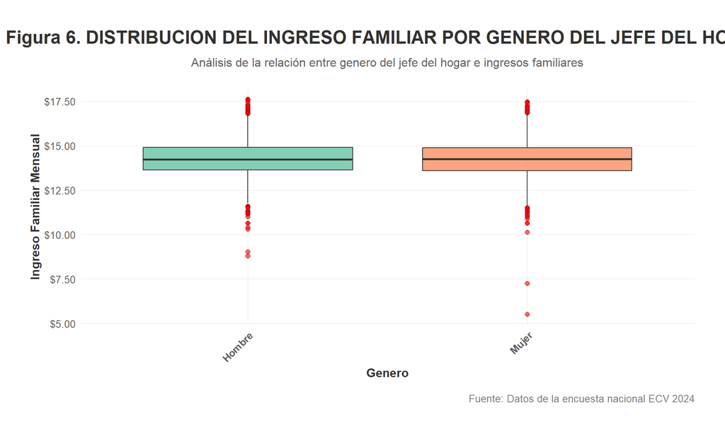

Además, la jefatura masculina está sobrerrepresentada, ya que tiene 63.8% hombres frente al 36.2% mujeres, lo cual condiciona la cantidad absoluta de observaciones por categoría y, por ende, la visibilidad de colas y outliers en cada caja.

### 3.3.3 Departamento

La tabla 7 revela la composición de la muestra estudiada en la región Pacífica colombiana.Valle del Cauca representa la mayor proporción con 2,125 observaciones (29.6%), seguido por Nariño con 2,055 casos (28.6%). En conjunto, estos dos departamentos concentran el 58.2% del total de la muestra, indicando una sobrerrepresentación relativa en el estudio. Cauca contribuye con 1912 hogares (26.6%), mientras que Chocó presenta la menor representación con 1088 casos (15.2%).

Tabla 7 Distribución de Frecuencias por Departamento

| Departamento | Frecuencia | Porcentaje (%) | Porcentaje Acumulado (%) |
| --- | --- | --- | --- |
| Valle del Cauca | 2125 | 29.6 | 29.6 |
| Nariño | 2055 | 28.6 | 58.2 |
| Cauca | 1912 | 26.6 | 84.8 |
| Chocó | 1088 | 15.2 | 100.0 |

Nota: Fuente: Elaboración propia con base en ECV DANE 2024

# 4 Estimacion del modelo de regresion multiple

Figura 8. Resultados del modelo de regresión lineal múltiple

Variable

Coeficiente

Error Estándar

Estadístico t

Valor p

Sig.

(Intercept)

12.8239

0.07211

177.82801

2e-16

***

SexoMujer

-0.04196

0.01888

-2.22284

2.626e-02

EstudiosSecundaria

0.267

0.05534

4.82511

***

EstudiosTécnica/Tecnológica

0.7964

0.06105

13.04548

2e-16

***

EstudiosUniversitaria

1.29058

0.06132

21.04689

2e-16

***

EstudiosPostgrado

2.09482

0.0696

30.09835

2e-16

***

`C. personas en el hogar`

0.22975

0.00822

27.9611

2e-16

***

Edad

0.00097

0.00059

1.6388

1.013e-01

`Horas trabajadas la semana pasada`

0.00895

0.00062

14.3254

2e-16

***

DepartamentoChocó

-0.11779

0.02978

-3.95485

8.000e-05

***

DepartamentoNariño

-0.06647

0.02445

-2.7185

6.570e-03

DepartamentoValle del Cauca

0.20043

0.02463

8.13644

2e-16

***

R² ajustado

0.398

F

432.53

Valor p (modelo)

0.00e+00

N

7180

Nota: Elaboración propia con base en ECV DANE 2024.

Tabla 12. Predicciones de Ingreso Familiar para Diferentes Escenarios

| Sexo | Estudios | Personas | Edad | Horas | Departamento | Log(Ingreso) | Ingreso Predicho (COP) |
| --- | --- | --- | --- | --- | --- | --- | --- |
| Mujer | Secundaria | 2 | 49 | 44 | Valle del Cauca | 14.150 | 1,397,315 |
| Mujer | Universitaria | 4 | 35 | 35 | Cauca | 15.339 | 4,586,501 |
| Hombre | Postgrado | 2 | 50 | 45 | Valle del Cauca | 16.030 | 9,154,552 |
| Mujer | Secundaria | 3 | 40 | 30 | Nariño | 13.979 | 1,177,503 |
| Hombre | Técnica/Tecnológica | 4 | 42 | 48 | Chocó | 14.892 | 2,933,593 |

Nota: Elaboración propia con base en ECV DANE 2024. Los ingresos predichos representan el ingreso total mensual del hogar.

# 5 Resultados del modelo

## 5.1 Diagnóstico Gráfico de Supuestos

El procedimiento gráfico ejecutado con plot(model) permite evaluar de manera conjunta la normalidad de los residuos, la homocedasticidad, la linealidad de la relación funcional, y la presencia de valores atípicos e influyentes, todo en una misma rutina diagnóstica

### 5.1.1 Lineal

Se verifica que la relación entre la variable dependiente y los predictores sea aproximadamente lineal a partir del gráfico de residuos frente a valores ajustados. En ausencia de patrones curvos o sistemáticos, se asume que el supuesto de linealidad es razonable.

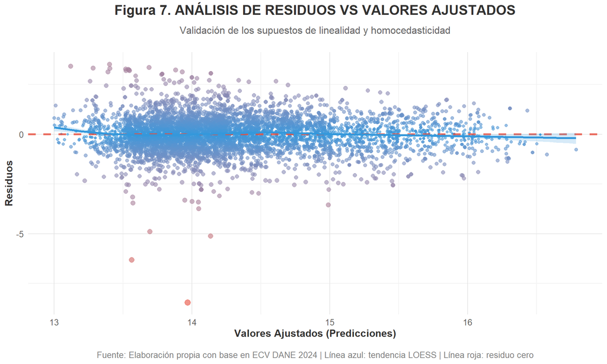

### 5.1.2 Normalidad

El Q-Q plot generado por plot(model) facilita la evaluación de si los residuos se distribuyen normalmente, indispensable para la validez de la inferencia sobre los coeficientes. Si los puntos del Q-Q plot se alinean en torno a la diagonal, la normalidad puede asumirse

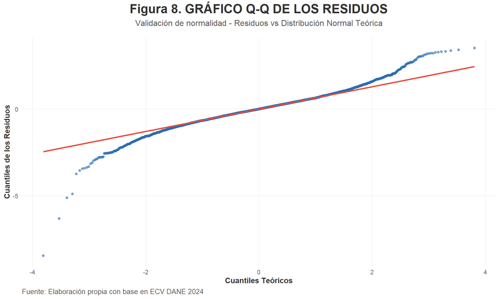

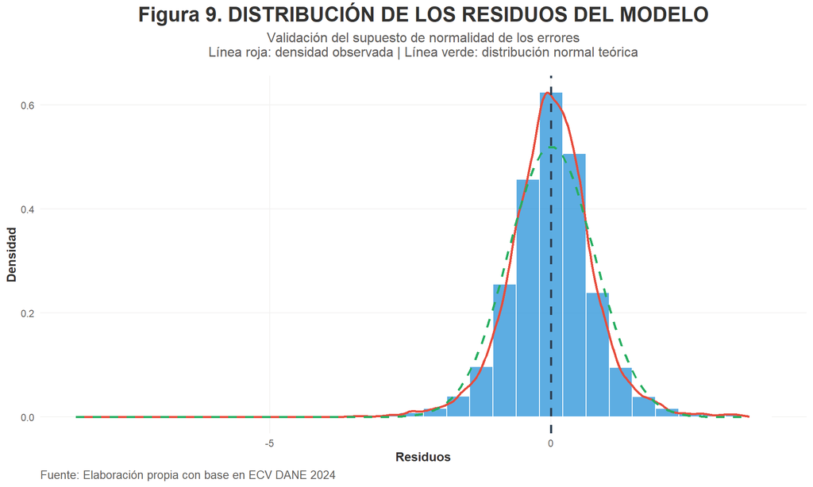